# Chapter 10

DJM

10 March 2020

# Quick review of OLS

- OLS stands for “ordinary least-squares”.
- Essentially, it means “solve the least-squares problem”

$$\widehat{\beta} = \underset{\beta}{\textrm{argmin}} \sum_{i=1}^n (x_i^\top\beta - y_i)^2 = (X^\top X)^{-1} X^\top Y$$

- The hat matrix is

$$\widehat{Y} = X\widehat{\beta} = X(X^\top X)^{-1} X^\top Y = HY$$

- The Gauss-Markov theorem says if:
  1. $Y_i = x^\top_i \beta+\epsilon_i$
  2. $\mathbb{E}\left[ \epsilon_i \right] = 0$
  3. $\mathbb{V}\left[ \epsilon_i \right]=\sigma^2 <\infty$
  4. $\mathrm{Cov}\left[\epsilon_i,\ \epsilon_j\right]=0$

Then $\widehat{\beta}$ has the smallest variance of all possible unbiased estimators for $\beta$.

# What is WLS and why use it?

- Weighted least-squares (WLS) is simply
  $$\widehat{\beta} = \underset{\beta}{\textrm{argmin}} \sum_{i=1}^n w_i( x_i^\top\beta - y_i)^2 = (X^\top WX)^{-1}X^\top WY$$
- If some of those assumptions for G-M are violated, in particular, if $\mathbb{V}\left[ \epsilon_i \right]$ depends on $x_i$ (notated like $\sigma^2(x_i))$, then we lose the optimality.
- Aside: Gauss-Markov is a commonly used justification for OLS in applied work. The logic goes like this: (1) unbiased is good, (2) G-M says OLS is the best linear model which is unbiased. The problem is that (1) is wrong. Unbiased may be good, but often a little bias is better.
- So what does WLS do?
  1. It **is** optimal, in the sense of G-M, if $\mathbb{V}\left[ \epsilon_i \right]=\sigma^2_i$.
  2. You’ve already used it (see next slide).
  3. What if you want to predict $Y_i$ which have other structures like $y_i \in \{0,1\}$? The algorithms for the new estimators (often called GLS for generalized least squares) use WLS (logistic regression is one example we are building to).

# You already used WLS

- I said you already did this. It is convenient that Kernel regression **is** WLS.
- In particular Kernel regression looks like
  $$\widehat{c} = \underset{c}{\textrm{argmin}} \sum_{j=1}^n \sum_{i=1}^n w_{ij}(c_j - y_i)^2 \quad w_{ij} = \frac{K((x_i-x_j)/h)}{\sum_{i=1}^n K((x_i-x_j)/h)}$$
  This is locally constant regression.
- You don’t need to understand this formula, but it can be useful, and it provides some justification for WLS based on previous ideas.

# What goes wrong with heteroskedasticity?

- So suppose $\mathbb{V}\left[ \epsilon_i \right] = \sigma^2(x_i)$. That is our “homoskedasticity” assumption is violated. Should we care?
- What if we just use OLS (that is `lm`) anyway?
- Some things don’t change.
  1. We still have that $\mathbb{E}\left[ \widehat{\beta} \right] = \beta$. That is OLS **is** still unbiased.
  2. We still have that OLS minimizes the sum of squared residuals: among all lines, OLS makes $\sum_{i=1}^n (x_i^\top \widehat{\beta}-y_i)^2$ as small as possible.
- Some things **do** change.
  1. OLS no longer has the best variance of all unbiased estimators (WLS does).
  2. The standard errors that `R` produces are wrong. They make it seem “more certain” than is correct (could use the bootstrap to fix it though).
  3. So are the $F$-tests and $p$-values (again, the bootstrap).

# Log squared residuals

# So why not?

# What’s the Oracle?

# A big example

- This is a (slightly modified) portion of a real job interview.
- It is a very simple application of heteroskedasticity.
- Heteroskedasticity appears frequently with financial data, so those companies like to see if you can handle it.

# The set up

- The dataset `jobInt` contains data from a simple linear model with heteroskedastic noise.
- In other words, for $i=1,\ldots,250$,

$$y_i = \beta_0 + \beta_1 x_i + \sigma(x_i) \epsilon_i \quad\quad\quad \epsilon_i \sim \mbox{N}(0,1).$$

- You know nothing about (the function) $\sigma(\cdot)$.
- Your goal is to estimate $(\beta_0,\ \beta_1)$ as well as possible, and provide a CI.

# How do I do this?

- First things first, EDA.

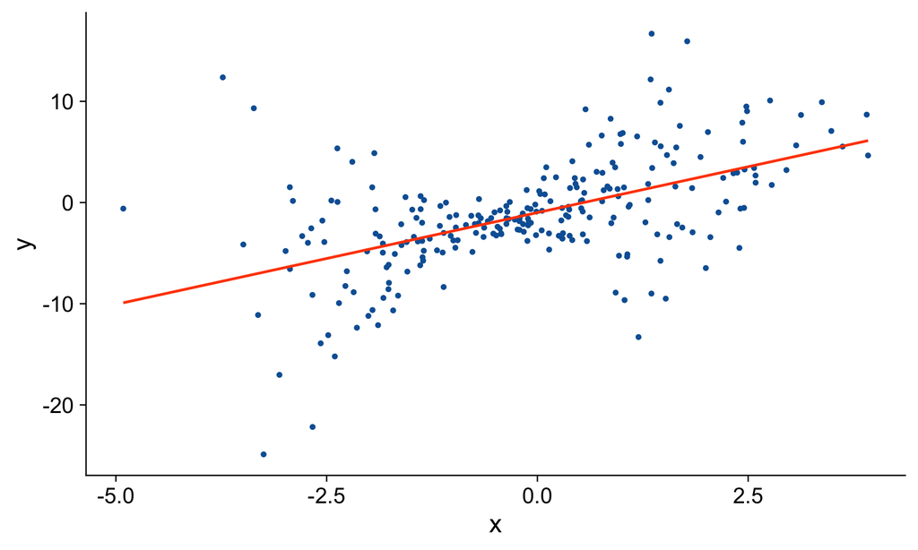

# qq-plot and residuals against x

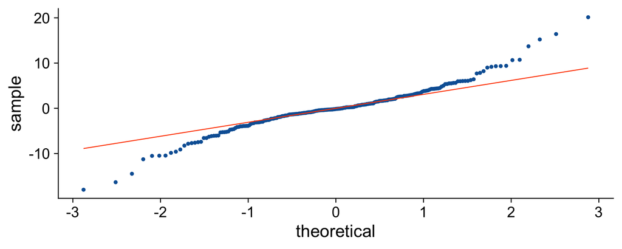

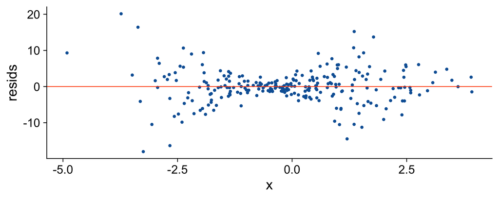

# residuals vs. fitted values

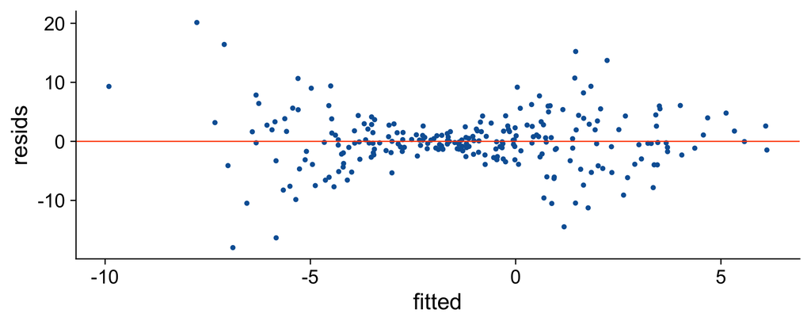

# So now what?

- We **know** that $\mathbb{E}\left[ Y \ \vert\ X=x \right] = \beta_0 + \beta_1 x$.
- We **know** that $\mathbb{E}\left[ \widehat{e}\ \vert\ X=x \right] = 0$.
- We **know** that $\mathbb{E}\left[ \widehat{e}^2 \ \vert\ X=x \right] = \sigma^2(x)$.
- So we want to try to estimate $\sigma^2(x)$ and $\beta_0$ and $\beta_1$ all at the same time.

# Oracle information

- If we knew $\beta_0$ and $\beta_1$, then we could use `npreg` to estimate $\sigma^2(x)$.
- If we **knew** $\sigma^2(x)$, then we could use WLS to estimate $\beta_0$ and $\beta_1$ (and all the SEs would be right!)
- But we don’t know either.

# Procedure

1. Use `lm` to estimate $\beta_0$ and $\beta_1$.
2. Now pretend that you “know” them, calculate $\log(\widehat{e}^2)$ and use `npreg` to estimate $\log \sigma^2(x)$.
3. Now pretend that you “know” $\sigma^2(x)$ (take $\exp$ of your estimate from 2.) and use WLS (with `lm(y~x, weights=1/sig2)`)
4. You could stop here. But since you now have “better” estimates of $\beta_1$ and $\beta_0$, it’s better to iterate 2 and 3 until some convergence.
5. Ok. Something converged, so you return the last estimates of $\beta_0$ and $\beta_1$. But the SEs are not right (because you “know” $\sigma^2(x)$ but you don’t **know** it).
6. To get SEs, use the bootstrap:
   1. Non-parametric: repeat 1-5 $B$ times on resampled data.
   2. Model-based: this is actually pretty hard here, better not to do it.

# Some code

- This code takes in data and does steps 1-5. It is **not** optimized for speed, but for readability, so run with care.

```r
heteroWLS <- function(dataFrame, tol = 1e-4, maxit = 100, track=FALSE){
  # inputs: a data object, optional: tolerance, max.iterations, and progress tracker (prints)
  # outputs: estimated betas and weights
  require(np)
  ols = lm(y~x, data=dataFrame)
  b = coefficients(ols)
  conv = FALSE
  for(iter in 1:maxit){ # don't let this run forever
    if(conv) break # if the b's stop moving, get out of the loop
    logSqResids = log(residuals(ols)^2)
    winv = exp(predict(npreg(logSqResids~x, data=dataFrame, tol=1e-2, ftol=1e-2)))
    winv[winv < tol] = tol # zero inverse weights are bad, make them small
    ols = lm(y~x, weights = 1/winv, data=dataFrame) #weights are 1 / estim.variance
    newb = coefficients(ols)
    conv.crit = sum((b-newb)^2) # calculate how much b moved
    if(track) cat('\n', iter, '/', maxit, ' conv.crit = ', conv.crit) # print progress
    conv = (conv.crit < tol) # check if the b's changed much
    b = newb # update the coefficient estimates
  }
  return(list(betas=b, weights = winv, log2resids = log(residuals(ols)^2)))
}
```

# Do it! (takes a little while…)

```r
resampWLS <- function(dataFrame,...){ # ... means options passed on
  rowSamp = sample(1:nrow(dataFrame), size=nrow(dataFrame), replace=TRUE)
  return(heteroWLS(dataFrame[rowSamp,],...)$betas) # passed things on if desired
}
B = 100 #
alp = .05
origBetas = heteroWLS(jobInt)
system.time(bootBetas <- replicate(B, resampWLS(jobInt, maxit=20)))
qq = apply(bootBetas, 1, quantile, probs=c(1-alp/2, alp/2))
CI = cbind(origBetas$betas, 2*origBetas$betas - t(qq))
colnames(CI) = c('coef', rev(colnames(CI)[2:3]))
```

```
##                   coef      2.5%      97.5%
## (Intercept) -0.9938074 -1.366213 -0.4183281
## x            2.0023640  1.714202  2.7401753
```

# Some plots

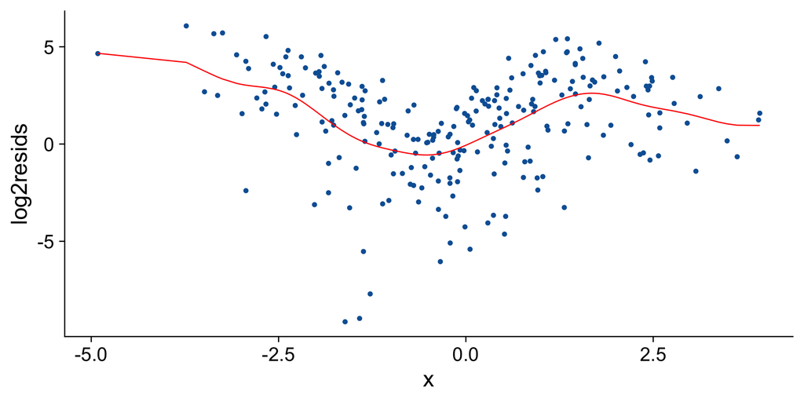

# Some caveats

- If we **care** about estimating $\sigma(\cdot)$, then what we did is ok.
- But we don’t.
- We only care about estimating $\beta_0$ and $\beta_1$.
- So better to use CV with leaving out $(y_i, x_i)$, instead of using CV to estimate $\sigma(\cdot)$ (which is what `npreg` is doing; it knows nothing about $y_i$)
- This takes a bit more work to code up (Try it!)

# Local linear vs. Kernels

- People often wonder whether to use local linear regression or Kernels.
- Like with many things, there isn’t really a cut-and-dried answer.
- Some practitioners prefer local linear regression.
- It’s main benefit is to correct “boundary bias”.
- Otherwise, not much different.

# Repeat of Ch. 4

- We can estimate this easily with both a kernel and local linear regression

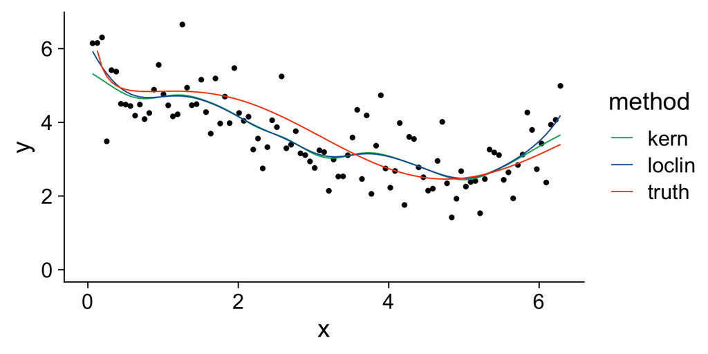

```r
kern = npreg(y~x, data = df)
loclin = npreg(y~x, data=df, regtype='ll')
df$kern = fitted(kern)
df$loclin = fitted(loclin)
df$truth = trueFunction(x)
dflines = pivot_longer(select(df,-y),-x, names_to = 'method')
ggplot(df, aes(x, y)) + geom_point() + xlim(0,2*pi) + ylim(0,max(df$y)) +
  geom_line(data=dflines, aes(x=x,y=value,color=method)) +
  scale_color_manual(values=c(green,blue,red))
```

# What is Loess?

- So kernel regressions are local constants, we then saw local linear regression which is quite similar.
- Why stop there? The next term is squared things, then cubics, then…
- Loess uses local polynomials (of some order) in a particular way (combining $k$-nearest neighbor regression with subsampling).
- It is actually quite cool, but it’s complexity makes it hard to deal with.
- Theoretically, one can show that Kernels are optimal, so it’s not really worth worrying too much about, but it can work well, and it doesn’t require installing a package.
- Here it is on my previous example

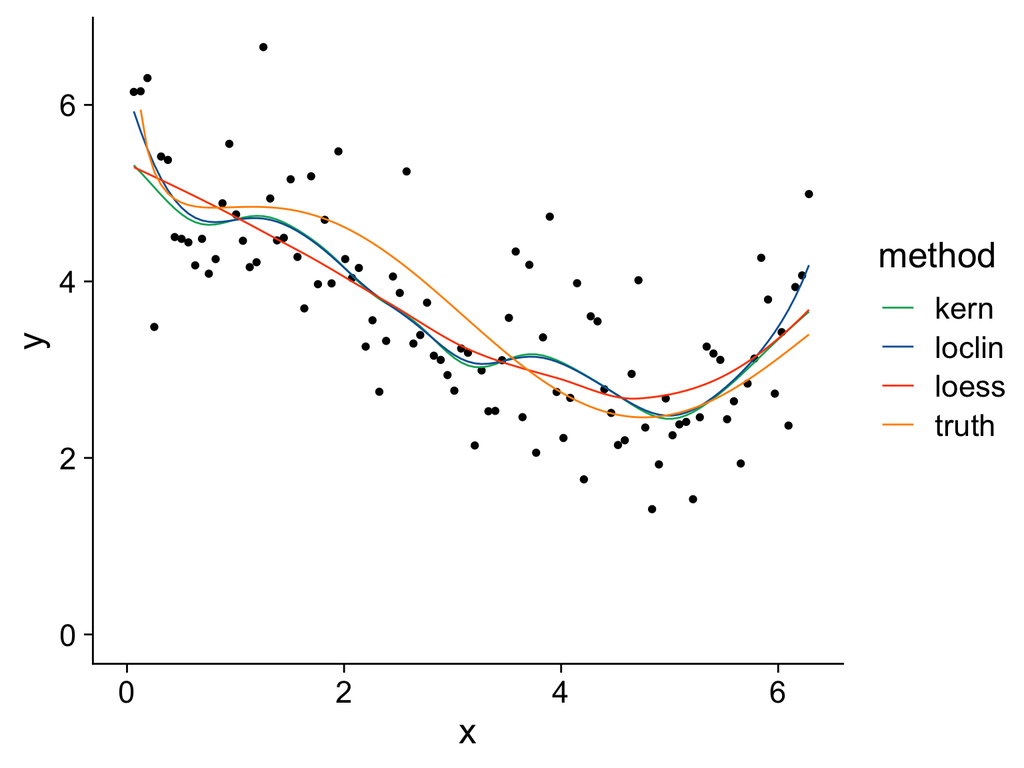

```r
ls = loess(y~x, data=df)
df$loess = fitted(ls)
dflines = pivot_longer(select(df,-y),-x,names_to='method')
ggplot(df, aes(x, y)) + geom_point() + xlim(0,2*pi) + ylim(0,max(df$y)) +
  geom_line(data=dflines, aes(x=x,y=value,color=method)) +
  scale_color_manual(values=c(green,blue,red,orange))
```